# Risk Factor Analysis

## Outcome Variable

**Outcome Variable:** y_rate_len

## Predictor Variables

**Intervention Variable:** trth2o

**Adjustment Set:**

unadjusted

## Stratifying Variables

The analysis was stratified on these variable(s):

- agecat
- studyid
- country

## Data Summary

| agecat | studyid | country | trth2o | n_cell | n |
| --- | --- | --- | --- | --- | --- |
| 0-3 months | ki0047075b-MAL-ED | BANGLADESH | 1 | 132 | 134 |
| 0-3 months | ki0047075b-MAL-ED | BANGLADESH | 0 | 2 | 134 |
| 0-3 months | ki0047075b-MAL-ED | BRAZIL | 1 | 11 | 82 |
| 0-3 months | ki0047075b-MAL-ED | BRAZIL | 0 | 71 | 82 |
| 0-3 months | ki0047075b-MAL-ED | INDIA | 1 | 2 | 5 |
| 0-3 months | ki0047075b-MAL-ED | INDIA | 0 | 3 | 5 |
| 0-3 months | ki0047075b-MAL-ED | NEPAL | 1 | 45 | 55 |
| 0-3 months | ki0047075b-MAL-ED | NEPAL | 0 | 10 | 55 |
| 0-3 months | ki0047075b-MAL-ED | PERU | 1 | 36 | 45 |
| 0-3 months | ki0047075b-MAL-ED | PERU | 0 | 9 | 45 |
| 0-3 months | ki0047075b-MAL-ED | SOUTH AFRICA | 1 | 1 | 9 |
| 0-3 months | ki0047075b-MAL-ED | SOUTH AFRICA | 0 | 8 | 9 |
| 0-3 months | ki0047075b-MAL-ED | TANZANIA, UNITED REPUBLIC OF | 1 | 6 | 38 |
| 0-3 months | ki0047075b-MAL-ED | TANZANIA, UNITED REPUBLIC OF | 0 | 32 | 38 |
| 0-3 months | ki1000108-CMC-V-BCS-2002 | INDIA | 1 | 25 | 25 |
| 0-3 months | ki1000108-CMC-V-BCS-2002 | INDIA | 0 | 0 | 25 |
| 0-3 months | ki1000108-IRC | INDIA | 1 | 118 | 118 |
| 0-3 months | ki1000108-IRC | INDIA | 0 | 0 | 118 |
| 0-3 months | ki1017093b-PROVIDE | BANGLADESH | 1 | 14 | 640 |
| 0-3 months | ki1017093b-PROVIDE | BANGLADESH | 0 | 626 | 640 |
| 0-3 months | ki1017093c-NIH-Crypto | BANGLADESH | 1 | 402 | 721 |
| 0-3 months | ki1017093c-NIH-Crypto | BANGLADESH | 0 | 319 | 721 |
| 0-3 months | ki1113344-GMS-Nepal | NEPAL | 1 | 1 | 4 |
| 0-3 months | ki1113344-GMS-Nepal | NEPAL | 0 | 3 | 4 |
| 3-6 months | ki0047075b-MAL-ED | BANGLADESH | 1 | 130 | 132 |
| 3-6 months | ki0047075b-MAL-ED | BANGLADESH | 0 | 2 | 132 |
| 3-6 months | ki0047075b-MAL-ED | BRAZIL | 1 | 13 | 103 |
| 3-6 months | ki0047075b-MAL-ED | BRAZIL | 0 | 90 | 103 |
| 3-6 months | ki0047075b-MAL-ED | INDIA | 1 | 3 | 7 |
| 3-6 months | ki0047075b-MAL-ED | INDIA | 0 | 4 | 7 |

[output cut: 162 more lines]

The following strata were considered:

- agecat: 0-3 months, studyid: ki0047075b-MAL-ED, country: BANGLADESH
- agecat: 0-3 months, studyid: ki0047075b-MAL-ED, country: BRAZIL
- agecat: 0-3 months, studyid: ki0047075b-MAL-ED, country: INDIA
- agecat: 0-3 months, studyid: ki0047075b-MAL-ED, country: NEPAL
- agecat: 0-3 months, studyid: ki0047075b-MAL-ED, country: PERU
- agecat: 0-3 months, studyid: ki0047075b-MAL-ED, country: SOUTH AFRICA
- agecat: 0-3 months, studyid: ki0047075b-MAL-ED, country: TANZANIA, UNITED REPUBLIC OF
- agecat: 0-3 months, studyid: ki1000108-CMC-V-BCS-2002, country: INDIA
- agecat: 0-3 months, studyid: ki1000108-IRC, country: INDIA
- agecat: 0-3 months, studyid: ki1017093b-PROVIDE, country: BANGLADESH
- agecat: 0-3 months, studyid: ki1017093c-NIH-Crypto, country: BANGLADESH
- agecat: 0-3 months, studyid: ki1113344-GMS-Nepal, country: NEPAL
- agecat: 12-15 months, studyid: ki0047075b-MAL-ED, country: BANGLADESH
- agecat: 12-15 months, studyid: ki0047075b-MAL-ED, country: BRAZIL
- agecat: 12-15 months, studyid: ki0047075b-MAL-ED, country: INDIA
- agecat: 12-15 months, studyid: ki0047075b-MAL-ED, country: NEPAL
- agecat: 12-15 months, studyid: ki0047075b-MAL-ED, country: PERU
- agecat: 12-15 months, studyid: ki0047075b-MAL-ED, country: SOUTH AFRICA
- agecat: 12-15 months, studyid: ki0047075b-MAL-ED, country: TANZANIA, UNITED REPUBLIC OF
- agecat: 12-15 months, studyid: ki1000108-CMC-V-BCS-2002, country: INDIA
- agecat: 12-15 months, studyid: ki1000108-IRC, country: INDIA
- agecat: 12-15 months, studyid: ki1017093b-PROVIDE, country: BANGLADESH
- agecat: 12-15 months, studyid: ki1017093c-NIH-Crypto, country: BANGLADESH
- agecat: 12-15 months, studyid: ki1113344-GMS-Nepal, country: NEPAL
- agecat: 15-18 months, studyid: ki0047075b-MAL-ED, country: BANGLADESH
- agecat: 15-18 months, studyid: ki0047075b-MAL-ED, country: BRAZIL
- agecat: 15-18 months, studyid: ki0047075b-MAL-ED, country: INDIA
- agecat: 15-18 months, studyid: ki0047075b-MAL-ED, country: NEPAL
- agecat: 15-18 months, studyid: ki0047075b-MAL-ED, country: PERU
- agecat: 15-18 months, studyid: ki0047075b-MAL-ED, country: SOUTH AFRICA
- agecat: 15-18 months, studyid: ki0047075b-MAL-ED, country: TANZANIA, UNITED REPUBLIC OF
- agecat: 15-18 months, studyid: ki1000108-CMC-V-BCS-2002, country: INDIA
- agecat: 15-18 months, studyid: ki1000108-IRC, country: INDIA
- agecat: 15-18 months, studyid: ki1017093b-PROVIDE, country: BANGLADESH
- agecat: 15-18 months, studyid: ki1017093c-NIH-Crypto, country: BANGLADESH
- agecat: 15-18 months, studyid: ki1113344-GMS-Nepal, country: NEPAL
- agecat: 18-21 months, studyid: ki0047075b-MAL-ED, country: BANGLADESH
- agecat: 18-21 months, studyid: ki0047075b-MAL-ED, country: BRAZIL
- agecat: 18-21 months, studyid: ki0047075b-MAL-ED, country: INDIA
- agecat: 18-21 months, studyid: ki0047075b-MAL-ED, country: NEPAL
- agecat: 18-21 months, studyid: ki0047075b-MAL-ED, country: PERU
- agecat: 18-21 months, studyid: ki0047075b-MAL-ED, country: SOUTH AFRICA
- agecat: 18-21 months, studyid: ki0047075b-MAL-ED, country: TANZANIA, UNITED REPUBLIC OF
- agecat: 18-21 months, studyid: ki1000108-CMC-V-BCS-2002, country: INDIA
- agecat: 18-21 months, studyid: ki1000108-IRC, country: INDIA
- agecat: 18-21 months, studyid: ki1017093b-PROVIDE, country: BANGLADESH
- agecat: 18-21 months, studyid: ki1017093c-NIH-Crypto, country: BANGLADESH
- agecat: 18-21 months, studyid: ki1113344-GMS-Nepal, country: NEPAL
- agecat: 21-24 months, studyid: ki0047075b-MAL-ED, country: BANGLADESH
- agecat: 21-24 months, studyid: ki0047075b-MAL-ED, country: BRAZIL
- agecat: 21-24 months, studyid: ki0047075b-MAL-ED, country: INDIA
- agecat: 21-24 months, studyid: ki0047075b-MAL-ED, country: NEPAL
- agecat: 21-24 months, studyid: ki0047075b-MAL-ED, country: PERU
- agecat: 21-24 months, studyid: ki0047075b-MAL-ED, country: SOUTH AFRICA
- agecat: 21-24 months, studyid: ki0047075b-MAL-ED, country: TANZANIA, UNITED REPUBLIC OF
- agecat: 21-24 months, studyid: ki1000108-CMC-V-BCS-2002, country: INDIA
- agecat: 21-24 months, studyid: ki1000108-IRC, country: INDIA
- agecat: 21-24 months, studyid: ki1017093b-PROVIDE, country: BANGLADESH
- agecat: 21-24 months, studyid: ki1017093c-NIH-Crypto, country: BANGLADESH
- agecat: 21-24 months, studyid: ki1113344-GMS-Nepal, country: NEPAL
- agecat: 3-6 months, studyid: ki0047075b-MAL-ED, country: BANGLADESH
- agecat: 3-6 months, studyid: ki0047075b-MAL-ED, country: BRAZIL
- agecat: 3-6 months, studyid: ki0047075b-MAL-ED, country: INDIA
- agecat: 3-6 months, studyid: ki0047075b-MAL-ED, country: NEPAL
- agecat: 3-6 months, studyid: ki0047075b-MAL-ED, country: PERU
- agecat: 3-6 months, studyid: ki0047075b-MAL-ED, country: SOUTH AFRICA
- agecat: 3-6 months, studyid: ki0047075b-MAL-ED, country: TANZANIA, UNITED REPUBLIC OF
- agecat: 3-6 months, studyid: ki1000108-CMC-V-BCS-2002, country: INDIA
- agecat: 3-6 months, studyid: ki1000108-IRC, country: INDIA
- agecat: 3-6 months, studyid: ki1017093b-PROVIDE, country: BANGLADESH
- agecat: 3-6 months, studyid: ki1017093c-NIH-Crypto, country: BANGLADESH
- agecat: 3-6 months, studyid: ki1113344-GMS-Nepal, country: NEPAL
- agecat: 6-9 months, studyid: ki0047075b-MAL-ED, country: BANGLADESH
- agecat: 6-9 months, studyid: ki0047075b-MAL-ED, country: BRAZIL
- agecat: 6-9 months, studyid: ki0047075b-MAL-ED, country: INDIA
- agecat: 6-9 months, studyid: ki0047075b-MAL-ED, country: NEPAL
- agecat: 6-9 months, studyid: ki0047075b-MAL-ED, country: PERU
- agecat: 6-9 months, studyid: ki0047075b-MAL-ED, country: SOUTH AFRICA
- agecat: 6-9 months, studyid: ki0047075b-MAL-ED, country: TANZANIA, UNITED REPUBLIC OF
- agecat: 6-9 months, studyid: ki1000108-CMC-V-BCS-2002, country: INDIA
- agecat: 6-9 months, studyid: ki1000108-IRC, country: INDIA
- agecat: 6-9 months, studyid: ki1017093b-PROVIDE, country: BANGLADESH
- agecat: 6-9 months, studyid: ki1017093c-NIH-Crypto, country: BANGLADESH
- agecat: 6-9 months, studyid: ki1113344-GMS-Nepal, country: NEPAL
- agecat: 9-12 months, studyid: ki0047075b-MAL-ED, country: BANGLADESH
- agecat: 9-12 months, studyid: ki0047075b-MAL-ED, country: BRAZIL
- agecat: 9-12 months, studyid: ki0047075b-MAL-ED, country: INDIA
- agecat: 9-12 months, studyid: ki0047075b-MAL-ED, country: NEPAL
- agecat: 9-12 months, studyid: ki0047075b-MAL-ED, country: PERU
- agecat: 9-12 months, studyid: ki0047075b-MAL-ED, country: SOUTH AFRICA
- agecat: 9-12 months, studyid: ki0047075b-MAL-ED, country: TANZANIA, UNITED REPUBLIC OF
- agecat: 9-12 months, studyid: ki1000108-CMC-V-BCS-2002, country: INDIA
- agecat: 9-12 months, studyid: ki1000108-IRC, country: INDIA
- agecat: 9-12 months, studyid: ki1017093b-PROVIDE, country: BANGLADESH
- agecat: 9-12 months, studyid: ki1017093c-NIH-Crypto, country: BANGLADESH
- agecat: 9-12 months, studyid: ki1113344-GMS-Nepal, country: NEPAL

### Dropped Strata

Some strata were dropped due to rare outcomes:

- agecat: 0-3 months, studyid: ki0047075b-MAL-ED, country: BANGLADESH
- agecat: 0-3 months, studyid: ki0047075b-MAL-ED, country: INDIA
- agecat: 0-3 months, studyid: ki0047075b-MAL-ED, country: SOUTH AFRICA
- agecat: 0-3 months, studyid: ki1000108-CMC-V-BCS-2002, country: INDIA
- agecat: 0-3 months, studyid: ki1000108-IRC, country: INDIA
- agecat: 0-3 months, studyid: ki1113344-GMS-Nepal, country: NEPAL
- agecat: 3-6 months, studyid: ki0047075b-MAL-ED, country: BANGLADESH
- agecat: 3-6 months, studyid: ki0047075b-MAL-ED, country: INDIA
- agecat: 3-6 months, studyid: ki0047075b-MAL-ED, country: SOUTH AFRICA
- agecat: 3-6 months, studyid: ki1000108-CMC-V-BCS-2002, country: INDIA
- agecat: 3-6 months, studyid: ki1000108-IRC, country: INDIA
- agecat: 3-6 months, studyid: ki1113344-GMS-Nepal, country: NEPAL
- agecat: 6-9 months, studyid: ki0047075b-MAL-ED, country: BANGLADESH
- agecat: 6-9 months, studyid: ki0047075b-MAL-ED, country: INDIA
- agecat: 6-9 months, studyid: ki0047075b-MAL-ED, country: SOUTH AFRICA
- agecat: 6-9 months, studyid: ki1000108-CMC-V-BCS-2002, country: INDIA
- agecat: 6-9 months, studyid: ki1000108-IRC, country: INDIA
- agecat: 6-9 months, studyid: ki1113344-GMS-Nepal, country: NEPAL
- agecat: 9-12 months, studyid: ki0047075b-MAL-ED, country: BANGLADESH
- agecat: 9-12 months, studyid: ki0047075b-MAL-ED, country: INDIA
- agecat: 9-12 months, studyid: ki0047075b-MAL-ED, country: SOUTH AFRICA
- agecat: 9-12 months, studyid: ki1000108-CMC-V-BCS-2002, country: INDIA
- agecat: 9-12 months, studyid: ki1000108-IRC, country: INDIA
- agecat: 9-12 months, studyid: ki1113344-GMS-Nepal, country: NEPAL
- agecat: 12-15 months, studyid: ki0047075b-MAL-ED, country: BANGLADESH
- agecat: 12-15 months, studyid: ki0047075b-MAL-ED, country: INDIA
- agecat: 12-15 months, studyid: ki0047075b-MAL-ED, country: SOUTH AFRICA
- agecat: 12-15 months, studyid: ki1000108-CMC-V-BCS-2002, country: INDIA
- agecat: 12-15 months, studyid: ki1000108-IRC, country: INDIA
- agecat: 12-15 months, studyid: ki1113344-GMS-Nepal, country: NEPAL
- agecat: 15-18 months, studyid: ki0047075b-MAL-ED, country: BANGLADESH
- agecat: 15-18 months, studyid: ki0047075b-MAL-ED, country: INDIA
- agecat: 15-18 months, studyid: ki0047075b-MAL-ED, country: SOUTH AFRICA
- agecat: 15-18 months, studyid: ki1000108-CMC-V-BCS-2002, country: INDIA
- agecat: 15-18 months, studyid: ki1000108-IRC, country: INDIA
- agecat: 15-18 months, studyid: ki1113344-GMS-Nepal, country: NEPAL
- agecat: 18-21 months, studyid: ki0047075b-MAL-ED, country: BANGLADESH
- agecat: 18-21 months, studyid: ki0047075b-MAL-ED, country: INDIA
- agecat: 18-21 months, studyid: ki0047075b-MAL-ED, country: SOUTH AFRICA
- agecat: 18-21 months, studyid: ki1000108-CMC-V-BCS-2002, country: INDIA
- agecat: 18-21 months, studyid: ki1000108-IRC, country: INDIA
- agecat: 18-21 months, studyid: ki1113344-GMS-Nepal, country: NEPAL
- agecat: 21-24 months, studyid: ki0047075b-MAL-ED, country: BANGLADESH
- agecat: 21-24 months, studyid: ki0047075b-MAL-ED, country: INDIA
- agecat: 21-24 months, studyid: ki0047075b-MAL-ED, country: SOUTH AFRICA
- agecat: 21-24 months, studyid: ki1000108-CMC-V-BCS-2002, country: INDIA
- agecat: 21-24 months, studyid: ki1000108-IRC, country: INDIA
- agecat: 21-24 months, studyid: ki1113344-GMS-Nepal, country: NEPAL

## Methods Detail

We’re interested in the causal parameters $E[Y_a]$ for all values of $a \in \mathcal{A}$. These parameters represent the mean outcome if, possibly contrary to fact, we intervened to set all units to have $A=a$. Under the randomization and positivity assumptions, these are identified by the statistical parameters $\psi_a=E_W[E_{Y|A,W}(Y|A=a,W)]$. In addition, we’re interested in the mean of $Y$, $E[Y]$ under no intervention (the observed mean). We will estimate these parameters by using SuperLearner to fit the relevant likelihood factors – $E_{Y|A,W}(Y|A=a,W)$ and $p(A=a|W)$, and then updating our likelihood fit using a joint TMLE.

For unadjusted analyses ($W=\{\}$), initial likelihoods were estimated using Lrnr_glm to estimate the simple $E(Y|A)$ and Lrnr_mean to estimate $p(A)$. For adjusted analyses, a small library containing Lrnr_glmnet, Lrnr_xgboost, and Lrnr_mean was used.

Having estimated these parameters, we will then use the delta method to estimate relative risks and attributable risks relative to a prespecified baseline level of $A$.

# Results Detail

## Results Plots

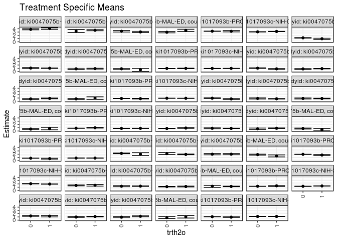

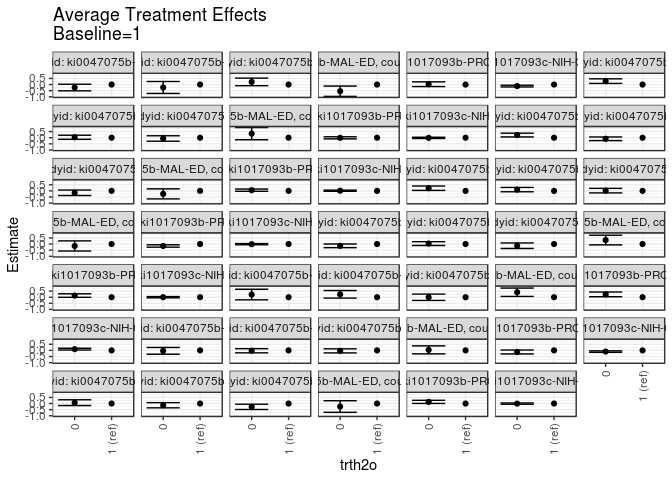

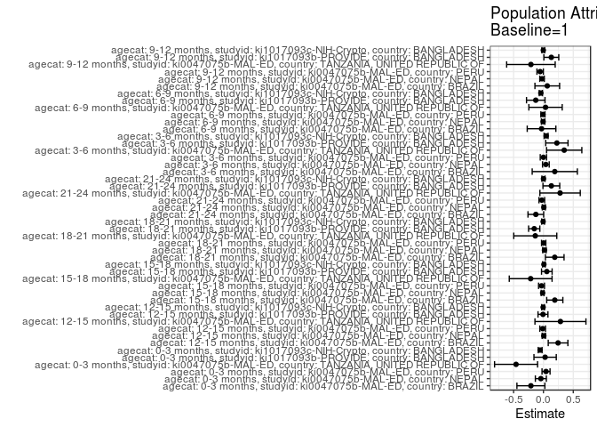

## Results Table

### Parameter: TSM

| agecat | studyid | country | intervention_level | baseline_level | estimate | ci_lower | ci_upper |
| --- | --- | --- | --- | --- | --- | --- | --- |
| 0-3 months | ki0047075b-MAL-ED | BRAZIL | 1 | NA | 4.0693006 | 3.8500599 | 4.2885413 |
| 0-3 months | ki0047075b-MAL-ED | BRAZIL | 0 | NA | 3.8267030 | 3.6694220 | 3.9839840 |
| 0-3 months | ki0047075b-MAL-ED | NEPAL | 1 | NA | 3.5461154 | 3.3899160 | 3.7023149 |
| 0-3 months | ki0047075b-MAL-ED | NEPAL | 0 | NA | 3.3070274 | 2.8443464 | 3.7697084 |
| 0-3 months | ki0047075b-MAL-ED | PERU | 1 | NA | 3.0273565 | 2.8251714 | 3.2295415 |
| 0-3 months | ki0047075b-MAL-ED | PERU | 0 | NA | 3.2438992 | 3.0076078 | 3.4801905 |
| 0-3 months | ki0047075b-MAL-ED | TANZANIA, UNITED REPUBLIC OF | 1 | NA | 3.4897230 | 3.1171369 | 3.8623092 |
| 0-3 months | ki0047075b-MAL-ED | TANZANIA, UNITED REPUBLIC OF | 0 | NA | 2.9447033 | 2.7483050 | 3.1411017 |
| 0-3 months | ki1017093b-PROVIDE | BANGLADESH | 1 | NA | 3.2297251 | 3.0416641 | 3.4177860 |
| 0-3 months | ki1017093b-PROVIDE | BANGLADESH | 0 | NA | 3.2583062 | 3.2206632 | 3.2959493 |
| 0-3 months | ki1017093c-NIH-Crypto | BANGLADESH | 1 | NA | 3.1845792 | 3.1324408 | 3.2367176 |
| 0-3 months | ki1017093c-NIH-Crypto | BANGLADESH | 0 | NA | 3.0595132 | 3.0110960 | 3.1079303 |
| 3-6 months | ki0047075b-MAL-ED | BRAZIL | 1 | NA | 2.0298802 | 1.6110471 | 2.4487134 |
| 3-6 months | ki0047075b-MAL-ED | BRAZIL | 0 | NA | 2.2471334 | 2.1384226 | 2.3558442 |
| 3-6 months | ki0047075b-MAL-ED | NEPAL | 1 | NA | 1.9448105 | 1.8354455 | 2.0541755 |
| 3-6 months | ki0047075b-MAL-ED | NEPAL | 0 | NA | 2.1819697 | 1.8940305 | 2.4699088 |
| 3-6 months | ki0047075b-MAL-ED | PERU | 1 | NA | 2.0066900 | 1.8345203 | 2.1788597 |
| 3-6 months | ki0047075b-MAL-ED | PERU | 0 | NA | 2.0034011 | 1.8105150 | 2.1962872 |
| 3-6 months | ki0047075b-MAL-ED | TANZANIA, UNITED REPUBLIC OF | 1 | NA | 1.4680425 | 1.1592662 | 1.7768187 |
| 3-6 months | ki0047075b-MAL-ED | TANZANIA, UNITED REPUBLIC OF | 0 | NA | 1.8739708 | 1.7296439 | 2.0182977 |
| 3-6 months | ki1017093b-PROVIDE | BANGLADESH | 1 | NA | 1.7408717 | 1.5523521 | 1.9293914 |
| 3-6 months | ki1017093b-PROVIDE | BANGLADESH | 0 | NA | 1.9711365 | 1.9368454 | 2.0054277 |
| 3-6 months | ki1017093c-NIH-Crypto | BANGLADESH | 1 | NA | 1.9608276 | 1.9133116 | 2.0083436 |
| 3-6 months | ki1017093c-NIH-Crypto | BANGLADESH | 0 | NA | 2.0606804 | 2.0049186 | 2.1164422 |
| 6-9 months | ki0047075b-MAL-ED | BRAZIL | 1 | NA | 1.5738760 | 1.3371394 | 1.8106127 |
| 6-9 months | ki0047075b-MAL-ED | BRAZIL | 0 | NA | 1.5373444 | 1.3975267 | 1.6771621 |
| 6-9 months | ki0047075b-MAL-ED | NEPAL | 1 | NA | 1.3167701 | 1.2358588 | 1.3976814 |
| 6-9 months | ki0047075b-MAL-ED | NEPAL | 0 | NA | 1.2865314 | 1.1364401 | 1.4366227 |
| 6-9 months | ki0047075b-MAL-ED | PERU | 1 | NA | 1.2022743 | 1.0669043 | 1.3376443 |
| 6-9 months | ki0047075b-MAL-ED | PERU | 0 | NA | 1.1614531 | 1.0656045 | 1.2573018 |

[output cut: 66 more lines]

### Parameter: E(Y)

| agecat | studyid | country | intervention_level | baseline_level | estimate | ci_lower | ci_upper |
| --- | --- | --- | --- | --- | --- | --- | --- |
| 0-3 months | ki0047075b-MAL-ED | BRAZIL | NA | NA | 3.8592466 | 3.7187660 | 3.9997272 |
| 0-3 months | ki0047075b-MAL-ED | NEPAL | NA | NA | 3.5026449 | 3.3476789 | 3.6576109 |
| 0-3 months | ki0047075b-MAL-ED | PERU | NA | NA | 3.0706650 | 2.9002220 | 3.2411079 |
| 0-3 months | ki0047075b-MAL-ED | TANZANIA, UNITED REPUBLIC OF | NA | NA | 3.0307591 | 2.8439041 | 3.2176140 |
| 0-3 months | ki1017093b-PROVIDE | BANGLADESH | NA | NA | 3.2576810 | 3.2206777 | 3.2946843 |
| 0-3 months | ki1017093c-NIH-Crypto | BANGLADESH | NA | NA | 3.1292449 | 3.0928504 | 3.1656393 |
| 3-6 months | ki0047075b-MAL-ED | BRAZIL | NA | NA | 2.2197131 | 2.1101066 | 2.3293196 |
| 3-6 months | ki0047075b-MAL-ED | NEPAL | NA | NA | 1.9853011 | 1.8803268 | 2.0902754 |
| 3-6 months | ki0047075b-MAL-ED | PERU | NA | NA | 2.0060188 | 1.8634433 | 2.1485943 |
| 3-6 months | ki0047075b-MAL-ED | TANZANIA, UNITED REPUBLIC OF | NA | NA | 1.8159811 | 1.6776334 | 1.9543288 |
| 3-6 months | ki1017093b-PROVIDE | BANGLADESH | NA | NA | 1.9657457 | 1.9318660 | 1.9996254 |
| 3-6 months | ki1017093c-NIH-Crypto | BANGLADESH | NA | NA | 2.0057973 | 1.9693775 | 2.0422170 |
| 6-9 months | ki0047075b-MAL-ED | BRAZIL | NA | NA | 1.5419552 | 1.4161616 | 1.6677488 |
| 6-9 months | ki0047075b-MAL-ED | NEPAL | NA | NA | 1.3116074 | 1.2397407 | 1.3834741 |
| 6-9 months | ki0047075b-MAL-ED | PERU | NA | NA | 1.1939434 | 1.0843398 | 1.3035471 |
| 6-9 months | ki0047075b-MAL-ED | TANZANIA, UNITED REPUBLIC OF | NA | NA | 1.2629098 | 0.9955016 | 1.5303180 |
| 6-9 months | ki1017093b-PROVIDE | BANGLADESH | NA | NA | 1.2824185 | 1.2571827 | 1.3076542 |
| 6-9 months | ki1017093c-NIH-Crypto | BANGLADESH | NA | NA | 1.3282695 | 1.2988292 | 1.3577098 |
| 9-12 months | ki0047075b-MAL-ED | BRAZIL | NA | NA | 1.2896896 | 1.1901580 | 1.3892213 |
| 9-12 months | ki0047075b-MAL-ED | NEPAL | NA | NA | 1.0747092 | 1.0020180 | 1.1474004 |
| 9-12 months | ki0047075b-MAL-ED | PERU | NA | NA | 1.1281439 | 1.0053147 | 1.2509730 |
| 9-12 months | ki0047075b-MAL-ED | TANZANIA, UNITED REPUBLIC OF | NA | NA | 0.8117127 | 0.5485045 | 1.0749209 |
| 9-12 months | ki1017093b-PROVIDE | BANGLADESH | NA | NA | 1.0499750 | 1.0230130 | 1.0769370 |
| 9-12 months | ki1017093c-NIH-Crypto | BANGLADESH | NA | NA | 1.1234745 | 1.0972274 | 1.1497215 |
| 12-15 months | ki0047075b-MAL-ED | BRAZIL | NA | NA | 1.1769612 | 1.1045524 | 1.2493699 |
| 12-15 months | ki0047075b-MAL-ED | NEPAL | NA | NA | 1.0278956 | 0.9678283 | 1.0879630 |
| 12-15 months | ki0047075b-MAL-ED | PERU | NA | NA | 0.8783001 | 0.7638220 | 0.9927782 |
| 12-15 months | ki0047075b-MAL-ED | TANZANIA, UNITED REPUBLIC OF | NA | NA | 0.7956749 | 0.6519279 | 0.9394219 |
| 12-15 months | ki1017093b-PROVIDE | BANGLADESH | NA | NA | 0.9597501 | 0.9335899 | 0.9859102 |
| 12-15 months | ki1017093c-NIH-Crypto | BANGLADESH | NA | NA | 0.9711395 | 0.9465805 | 0.9956985 |
| 15-18 months | ki0047075b-MAL-ED | BRAZIL | NA | NA | 1.0078031 | 0.9251335 | 1.0904728 |
| 15-18 months | ki0047075b-MAL-ED | NEPAL | NA | NA | 0.8737133 | 0.8117853 | 0.9356414 |
| 15-18 months | ki0047075b-MAL-ED | PERU | NA | NA | 0.8383703 | 0.7329602 | 0.9437805 |
| 15-18 months | ki0047075b-MAL-ED | TANZANIA, UNITED REPUBLIC OF | NA | NA | 0.7647144 | 0.6223905 | 0.9070384 |
| 15-18 months | ki1017093b-PROVIDE | BANGLADESH | NA | NA | 0.8560998 | 0.8320145 | 0.8801852 |
| 15-18 months | ki1017093c-NIH-Crypto | BANGLADESH | NA | NA | 0.9177168 | 0.8947657 | 0.9406678 |
| 18-21 months | ki0047075b-MAL-ED | BRAZIL | NA | NA | 0.9113468 | 0.8087233 | 1.0139703 |
| 18-21 months | ki0047075b-MAL-ED | NEPAL | NA | NA | 0.7759274 | 0.7112362 | 0.8406186 |
| 18-21 months | ki0047075b-MAL-ED | PERU | NA | NA | 0.8457955 | 0.7602887 | 0.9313023 |
| 18-21 months | ki0047075b-MAL-ED | TANZANIA, UNITED REPUBLIC OF | NA | NA | 0.6129126 | 0.4646003 | 0.7612249 |
| 18-21 months | ki1017093b-PROVIDE | BANGLADESH | NA | NA | 0.8393377 | 0.8153485 | 0.8633269 |
| 18-21 months | ki1017093c-NIH-Crypto | BANGLADESH | NA | NA | 0.7977755 | 0.7744353 | 0.8211158 |
| 21-24 months | ki0047075b-MAL-ED | BRAZIL | NA | NA | 0.7722472 | 0.7221195 | 0.8223749 |
| 21-24 months | ki0047075b-MAL-ED | NEPAL | NA | NA | 0.7915700 | 0.7335331 | 0.8496069 |
| 21-24 months | ki0047075b-MAL-ED | PERU | NA | NA | 0.7989125 | 0.7024314 | 0.8953937 |
| 21-24 months | ki0047075b-MAL-ED | TANZANIA, UNITED REPUBLIC OF | NA | NA | 0.7040721 | 0.5679942 | 0.8401499 |
| 21-24 months | ki1017093b-PROVIDE | BANGLADESH | NA | NA | 0.7631391 | 0.7377453 | 0.7885328 |
| 21-24 months | ki1017093c-NIH-Crypto | BANGLADESH | NA | NA | 0.7993353 | 0.7748026 | 0.8238681 |

### Parameter: ATE

| agecat | studyid | country | intervention_level | baseline_level | estimate | ci_lower | ci_upper |
| --- | --- | --- | --- | --- | --- | --- | --- |
| 0-3 months | ki0047075b-MAL-ED | BRAZIL | 1 | 1 | 0.0000000 | 0.0000000 | 0.0000000 |
| 0-3 months | ki0047075b-MAL-ED | BRAZIL | 0 | 1 | -0.2425976 | -0.5124194 | 0.0272242 |
| 0-3 months | ki0047075b-MAL-ED | NEPAL | 1 | 1 | 0.0000000 | 0.0000000 | 0.0000000 |
| 0-3 months | ki0047075b-MAL-ED | NEPAL | 0 | 1 | -0.2390880 | -0.7274239 | 0.2492479 |
| 0-3 months | ki0047075b-MAL-ED | PERU | 1 | 1 | 0.0000000 | 0.0000000 | 0.0000000 |
| 0-3 months | ki0047075b-MAL-ED | PERU | 0 | 1 | 0.2165427 | -0.0944435 | 0.5275289 |
| 0-3 months | ki0047075b-MAL-ED | TANZANIA, UNITED REPUBLIC OF | 1 | 1 | 0.0000000 | 0.0000000 | 0.0000000 |
| 0-3 months | ki0047075b-MAL-ED | TANZANIA, UNITED REPUBLIC OF | 0 | 1 | -0.5450197 | -0.9661999 | -0.1238395 |
| 0-3 months | ki1017093b-PROVIDE | BANGLADESH | 1 | 1 | 0.0000000 | 0.0000000 | 0.0000000 |
| 0-3 months | ki1017093b-PROVIDE | BANGLADESH | 0 | 1 | 0.0285811 | -0.1632102 | 0.2203725 |
| 0-3 months | ki1017093c-NIH-Crypto | BANGLADESH | 1 | 1 | 0.0000000 | 0.0000000 | 0.0000000 |
| 0-3 months | ki1017093c-NIH-Crypto | BANGLADESH | 0 | 1 | -0.1250661 | -0.1962182 | -0.0539139 |
| 3-6 months | ki0047075b-MAL-ED | BRAZIL | 1 | 1 | 0.0000000 | 0.0000000 | 0.0000000 |
| 3-6 months | ki0047075b-MAL-ED | BRAZIL | 0 | 1 | 0.2172532 | -0.2154583 | 0.6499647 |
| 3-6 months | ki0047075b-MAL-ED | NEPAL | 1 | 1 | 0.0000000 | 0.0000000 | 0.0000000 |
| 3-6 months | ki0047075b-MAL-ED | NEPAL | 0 | 1 | 0.2371592 | -0.0708500 | 0.5451684 |
| 3-6 months | ki0047075b-MAL-ED | PERU | 1 | 1 | 0.0000000 | 0.0000000 | 0.0000000 |
| 3-6 months | ki0047075b-MAL-ED | PERU | 0 | 1 | -0.0032889 | -0.2618377 | 0.2552599 |
| 3-6 months | ki0047075b-MAL-ED | TANZANIA, UNITED REPUBLIC OF | 1 | 1 | 0.0000000 | 0.0000000 | 0.0000000 |
| 3-6 months | ki0047075b-MAL-ED | TANZANIA, UNITED REPUBLIC OF | 0 | 1 | 0.4059284 | 0.0650868 | 0.7467700 |
| 3-6 months | ki1017093b-PROVIDE | BANGLADESH | 1 | 1 | 0.0000000 | 0.0000000 | 0.0000000 |
| 3-6 months | ki1017093b-PROVIDE | BANGLADESH | 0 | 1 | 0.2302648 | 0.0386518 | 0.4218778 |
| 3-6 months | ki1017093c-NIH-Crypto | BANGLADESH | 1 | 1 | 0.0000000 | 0.0000000 | 0.0000000 |
| 3-6 months | ki1017093c-NIH-Crypto | BANGLADESH | 0 | 1 | 0.0998528 | 0.0265920 | 0.1731136 |
| 6-9 months | ki0047075b-MAL-ED | BRAZIL | 1 | 1 | 0.0000000 | 0.0000000 | 0.0000000 |
| 6-9 months | ki0047075b-MAL-ED | BRAZIL | 0 | 1 | -0.0365316 | -0.3114739 | 0.2384106 |
| 6-9 months | ki0047075b-MAL-ED | NEPAL | 1 | 1 | 0.0000000 | 0.0000000 | 0.0000000 |
| 6-9 months | ki0047075b-MAL-ED | NEPAL | 0 | 1 | -0.0302387 | -0.2007498 | 0.1402724 |
| 6-9 months | ki0047075b-MAL-ED | PERU | 1 | 1 | 0.0000000 | 0.0000000 | 0.0000000 |
| 6-9 months | ki0047075b-MAL-ED | PERU | 0 | 1 | -0.0408212 | -0.2066886 | 0.1250463 |

[output cut: 66 more lines]

### Parameter: PAR

| agecat | studyid | country | intervention_level | baseline_level | estimate | ci_lower | ci_upper |
| --- | --- | --- | --- | --- | --- | --- | --- |
| 0-3 months | ki0047075b-MAL-ED | BRAZIL | 1 | NA | -0.2100540 | -0.4443730 | 0.0242650 |
| 0-3 months | ki0047075b-MAL-ED | NEPAL | 1 | NA | -0.0434706 | -0.1356025 | 0.0486614 |
| 0-3 months | ki0047075b-MAL-ED | PERU | 1 | NA | 0.0433085 | -0.0239485 | 0.1105656 |
| 0-3 months | ki0047075b-MAL-ED | TANZANIA, UNITED REPUBLIC OF | 1 | NA | -0.4589640 | -0.8193765 | -0.0985514 |
| 0-3 months | ki1017093b-PROVIDE | BANGLADESH | 1 | NA | 0.0279559 | -0.1590409 | 0.2149528 |
| 0-3 months | ki1017093c-NIH-Crypto | BANGLADESH | 1 | NA | -0.0553344 | -0.0871403 | -0.0235284 |
| 3-6 months | ki0047075b-MAL-ED | BRAZIL | 1 | NA | 0.1898329 | -0.1885237 | 0.5681894 |
| 3-6 months | ki0047075b-MAL-ED | NEPAL | 1 | NA | 0.0404906 | -0.0155723 | 0.0965535 |
| 3-6 months | ki0047075b-MAL-ED | PERU | 1 | NA | -0.0006712 | -0.0534376 | 0.0520952 |
| 3-6 months | ki0047075b-MAL-ED | TANZANIA, UNITED REPUBLIC OF | 1 | NA | 0.3479386 | 0.0525710 | 0.6433063 |
| 3-6 months | ki1017093b-PROVIDE | BANGLADESH | 1 | NA | 0.2248740 | 0.0380305 | 0.4117176 |
| 3-6 months | ki1017093c-NIH-Crypto | BANGLADESH | 1 | NA | 0.0449697 | 0.0117696 | 0.0781698 |
| 6-9 months | ki0047075b-MAL-ED | BRAZIL | 1 | NA | -0.0319209 | -0.2721732 | 0.2083315 |
| 6-9 months | ki0047075b-MAL-ED | NEPAL | 1 | NA | -0.0051627 | -0.0343796 | 0.0240542 |
| 6-9 months | ki0047075b-MAL-ED | PERU | 1 | NA | -0.0083309 | -0.0424998 | 0.0258381 |
| 6-9 months | ki0047075b-MAL-ED | TANZANIA, UNITED REPUBLIC OF | 1 | NA | 0.0351880 | -0.2440636 | 0.3144396 |
| 6-9 months | ki1017093b-PROVIDE | BANGLADESH | 1 | NA | -0.1287659 | -0.2838729 | 0.0263412 |
| 6-9 months | ki1017093c-NIH-Crypto | BANGLADESH | 1 | NA | -0.0438533 | -0.0705267 | -0.0171800 |
| 9-12 months | ki0047075b-MAL-ED | BRAZIL | 1 | NA | 0.0640990 | -0.1427519 | 0.2709499 |
| 9-12 months | ki0047075b-MAL-ED | NEPAL | 1 | NA | -0.0234457 | -0.0612752 | 0.0143839 |
| 9-12 months | ki0047075b-MAL-ED | PERU | 1 | NA | -0.0552410 | -0.1089496 | -0.0015325 |
| 9-12 months | ki0047075b-MAL-ED | TANZANIA, UNITED REPUBLIC OF | 1 | NA | -0.2098030 | -0.6164757 | 0.1968697 |
| 9-12 months | ki1017093b-PROVIDE | BANGLADESH | 1 | NA | 0.1320965 | 0.0074373 | 0.2567557 |
| 9-12 months | ki1017093c-NIH-Crypto | BANGLADESH | 1 | NA | -0.0023058 | -0.0263988 | 0.0217873 |
| 12-15 months | ki0047075b-MAL-ED | BRAZIL | 1 | NA | 0.2449728 | 0.0802340 | 0.4097116 |
| 12-15 months | ki0047075b-MAL-ED | NEPAL | 1 | NA | 0.0061047 | -0.0220875 | 0.0342969 |
| 12-15 months | ki0047075b-MAL-ED | PERU | 1 | NA | -0.0132341 | -0.0605854 | 0.0341173 |
| 12-15 months | ki0047075b-MAL-ED | TANZANIA, UNITED REPUBLIC OF | 1 | NA | 0.2848826 | -0.1423753 | 0.7121405 |
| 12-15 months | ki1017093b-PROVIDE | BANGLADESH | 1 | NA | -0.0077801 | -0.0909357 | 0.0753756 |
| 12-15 months | ki1017093c-NIH-Crypto | BANGLADESH | 1 | NA | -0.0055616 | -0.0284224 | 0.0172993 |
| 15-18 months | ki0047075b-MAL-ED | BRAZIL | 1 | NA | 0.1901176 | 0.0548437 | 0.3253914 |
| 15-18 months | ki0047075b-MAL-ED | NEPAL | 1 | NA | -0.0137889 | -0.0386339 | 0.0110561 |
| 15-18 months | ki0047075b-MAL-ED | PERU | 1 | NA | -0.0320279 | -0.0815606 | 0.0175048 |
| 15-18 months | ki0047075b-MAL-ED | TANZANIA, UNITED REPUBLIC OF | 1 | NA | -0.2141583 | -0.5727752 | 0.1444586 |
| 15-18 months | ki1017093b-PROVIDE | BANGLADESH | 1 | NA | 0.0566019 | -0.0319892 | 0.1451930 |
| 15-18 months | ki1017093c-NIH-Crypto | BANGLADESH | 1 | NA | 0.0074691 | -0.0153315 | 0.0302697 |
| 18-21 months | ki0047075b-MAL-ED | BRAZIL | 1 | NA | 0.1893980 | 0.0334704 | 0.3453256 |
| 18-21 months | ki0047075b-MAL-ED | NEPAL | 1 | NA | 0.0169363 | -0.0128824 | 0.0467551 |
| 18-21 months | ki0047075b-MAL-ED | PERU | 1 | NA | 0.0040474 | -0.0320064 | 0.0401012 |
| 18-21 months | ki0047075b-MAL-ED | TANZANIA, UNITED REPUBLIC OF | 1 | NA | -0.1369223 | -0.4974390 | 0.2235944 |
| 18-21 months | ki1017093b-PROVIDE | BANGLADESH | 1 | NA | -0.1544229 | -0.2486469 | -0.0601988 |
| 18-21 months | ki1017093c-NIH-Crypto | BANGLADESH | 1 | NA | -0.0054254 | -0.0293425 | 0.0184917 |
| 21-24 months | ki0047075b-MAL-ED | BRAZIL | 1 | NA | -0.1275781 | -0.2590061 | 0.0038499 |
| 21-24 months | ki0047075b-MAL-ED | NEPAL | 1 | NA | 0.0065464 | -0.0197553 | 0.0328481 |
| 21-24 months | ki0047075b-MAL-ED | PERU | 1 | NA | -0.0273594 | -0.0750902 | 0.0203714 |
| 21-24 months | ki0047075b-MAL-ED | TANZANIA, UNITED REPUBLIC OF | 1 | NA | 0.2788832 | -0.0592694 | 0.6170358 |
| 21-24 months | ki1017093b-PROVIDE | BANGLADESH | 1 | NA | 0.1323795 | -0.0082965 | 0.2730555 |
| 21-24 months | ki1017093c-NIH-Crypto | BANGLADESH | 1 | NA | 0.0005674 | -0.0261881 | 0.0273230 |